# Assignment: Electricity Market Prices

Caner ucar

12/10/2020

## Preparation of Data

First, we import the .xls file from the computer and check it.

```r
data <- readxl::read_xls("/Users/cucar/Downloads/ptf-smf.xls")
data %>% glimpse()
```

```
## Rows: 720
## Columns: 6
## $ Tarih                                 <chr> "01.09.20 00:00", "01.09.20 01:…
## $ PTF                                   <chr> "302,39", "300,25", "292,64", "…
## $ SMF                                   <chr> "332,39", "325,25", "317,64", "…
## $ `Pozitif Dengesizlik Fiyatı (TL/MWh)` <chr> "293,32", "291,24", "283,86", "…
## $ `Negatif Dengesizlik Fiyatı (TL/MWh)` <chr> "342,36", "335,01", "327,17", "…
## $ `SMF Yön`                             <chr> "↑ Enerji Açığı", "↑ Enerji Açı…
```

Then, we change data types into appropriate ones (dttm, double and strings) and rename headlines. After that, we prepare new data table with headlines we are interested in for analyzing.

First seven data are shown on the table;

```r
data$Tarih=as.POSIXct(data$Tarih,format='%d.%m.%y %H:%M')

chr_to_double = function(char_string){
  numeric = as.numeric(sub(',', '.',sub('.', '', char_string, fixed = TRUE)))
  return(numeric)
}

data$PTF <- chr_to_double(data$PTF)
data$SMF <- chr_to_double(data$SMF)
data$`Pozitif Dengesizlik Fiyatı (TL/MWh)` <- chr_to_double(data$`Pozitif Dengesizlik Fiyatı (TL/MWh)`)
data$`Negatif Dengesizlik Fiyatı (TL/MWh)` <- chr_to_double(data$`Negatif Dengesizlik Fiyatı (TL/MWh)`)

names(data)[1]="Date_Time"
names(data)[2]="MCP"
names(data)[3]="SMP"
names(data)[4]="Positive Imbalance Price (TRY/MWh)"
names(data)[5]="Negative Imbalance Price (TRY/MWh)"
names(data)[6]="Energy Balance Check"

data_1 <- data %>% select(Date_Time, MCP, SMP) %>% mutate(Day=weekdays(Date_Time)) %>% mutate(Day_Number=day(Date_Time)) %>% mutate(Hours=hour(Date_Time))

knitr::kable(data_1[1:7,], format="markdown", align='cc')
```

| Date_Time | MCP | SMP | Day | Day_Number | Hours |
| --- | --- | --- | --- | --- | --- |
| 2020-09-01 00:00:00 | 302.39 | 332.39 | Salı | 1 | 0 |
| 2020-09-01 01:00:00 | 300.25 | 325.25 | Salı | 1 | 1 |
| 2020-09-01 02:00:00 | 292.64 | 317.64 | Salı | 1 | 2 |
| 2020-09-01 03:00:00 | 290.00 | 320.00 | Salı | 1 | 3 |
| 2020-09-01 04:00:00 | 290.00 | 330.00 | Salı | 1 | 4 |
| 2020-09-01 05:00:00 | 290.00 | 339.00 | Salı | 1 | 5 |
| 2020-09-01 06:00:00 | 292.01 | 342.01 | Salı | 1 | 6 |

## Analyzing the data by visualizing it with plots

After arranging the data table, we will look for average market clearing price and average system marginal price on hourly basis for September 2020 in Turkey by this code;

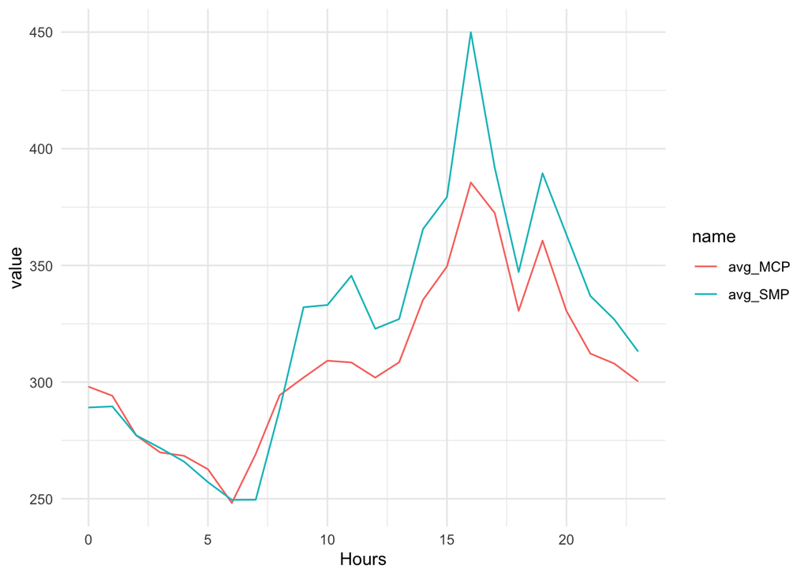

```r
data_1 %>% group_by(Hours) %>% summarise(avg_MCP=mean(MCP),avg_SMP=mean(SMP)) %>% pivot_longer(.,-Hours) %>% ggplot(aes(x=Hours, y=value ,color=name)) + geom_line() + theme_minimal()
```

As is seen from the plot, average SMP is lower than average MCP after midnight until morning. Therefore, we say that system has energy deficit when people are awake in Turkey. Peak time for energy consumption is around 16:00-17:00.

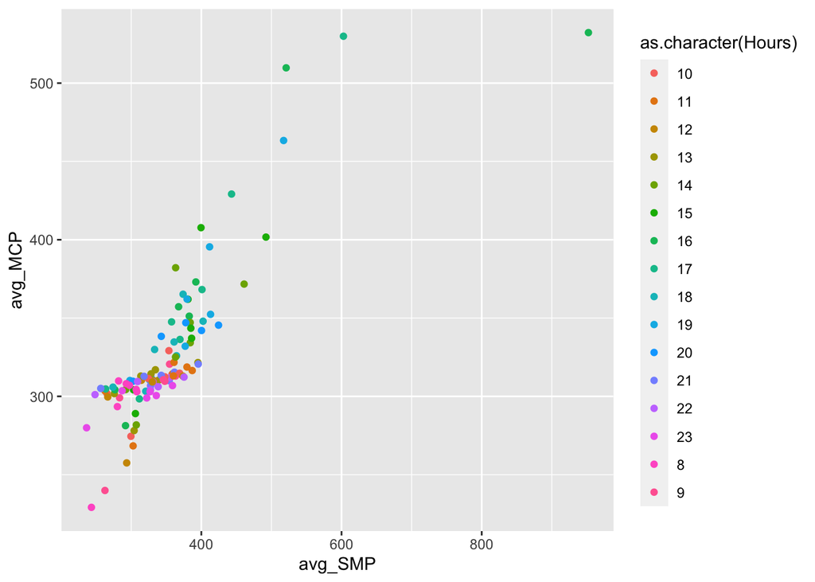

```r
data_1  %>% filter(Hours >= 8, Hours <= 24) %>% group_by(Day,Hours) %>%
  summarise(avg_MCP=mean(MCP),avg_SMP=mean(SMP)) %>%
  ggplot(.,aes(x=avg_SMP,y=avg_MCP, color=as.character(Hours))) +
    geom_point()
```